# Predicting the World Cup with Machine Learning

## Which machine learning algorithm would be most efficient to predict the winner of the world cup?

[figure not shown]

Our goal is to use determine which machine learning algotithm would be most efficient to predict the winner of the world cup.  
Data Source  
[www.kaggle.com/datasets/martj42/international-football-results-from-1872-to-2017](https://www.kaggle.com/datasets/martj42/international-football-results-from-1872-to-2017?resource=download&select=shootouts.csv)

Here is a link to all the steps in the data cleansing process: Fifa World Cup Data Cleansing

#### These were the steps taken to determine what Machine Learning algorithm would be most efficient for our data set

```python
import os
import pandas as pd
import numpy as np
from sklearn.neighbors import KNeighborsRegressor
import seaborn as sns
from scipy.stats import poisson
from sklearn.metrics import mean_squared_error
import numpy as np
from sklearn.linear_model import LinearRegression
from sklearn.model_selection import train_test_split
from sklearn import datasets, linear_model
from sklearn.discriminant_analysis import LinearDiscriminantAnalysis
from sklearn.linear_model import LassoCV
from sklearn.linear_model import RidgeCV
```

```python
df = pd.read_csv("/Users/ethan/Downloads/Data/Fifa_world_cup.csv", sep=",")
df=df.drop(["Unnamed: 0"], axis = 1)
```

```python
mean_goals = sum(df["home_team_score"])/(len(df))
print(mean_goals)
mean_goals_dF = sum(df["away_team_score"])/(len(df))
print(mean_goals_dF)
```

```
1.5448483741322616
1.0533430763609792
```

```python
df_home = df[['home_team', "home_team_fifa_rank","home_team_score","away_team_score"]]
df_away = df[['away_team', "away_team_fifa_rank","home_team_score","away_team_score"]]

df_home = df_home.rename(columns={'home_team': "Team", "home_team_fifa_rank":"fifa_rank","home_team_score":"Goals","away_team_score":"Goals_Conceded"})
df_away = df_away.rename(columns={'away_team': "Team", "away_team_fifa_rank":"fifa_rank","home_team_score": "Goals_Conceded","away_team_score":"Goals"})

df_team = pd.concat([df_home,df_away],ignore_index= True).groupby("Team").mean()
```

Calculating Offense Strength is dividing the team’s average number of goals scored by the average number of goals allowed. Calculating Defence Strength is dividing the team’s average number of goals allowed by the average number of goals allowed.

```python
df_team["Of_strength"]= df_team["Goals"]/mean_goals
df_team["Df_strength"]= df_team["Goals_Conceded"]/mean_goals_dF
df_team
```

| Team | fifa_rank | Goals | Goals_Conceded | Of_strength | Df_strength |
| --- | --- | --- | --- | --- | --- |
| Afghanistan | 156.062500 | 1.262500 | 1.600000 | 0.817232 | 1.518973 |
| Albania | 63.333333 | 1.029630 | 1.133333 | 0.666492 | 1.075939 |
| Algeria | 38.448276 | 1.786207 | 0.882759 | 1.156234 | 0.838054 |
| American Samoa | 199.600000 | 1.133333 | 4.200000 | 0.733621 | 3.987305 |
| Andorra | 174.450450 | 0.324324 | 2.369369 | 0.209939 | 2.249380 |
| ... | ... | ... | ... | ... | ... |
| Vietnam | 125.410714 | 1.589286 | 1.232143 | 1.028765 | 1.169745 |
| Wales | 38.308271 | 1.112782 | 1.120301 | 0.720318 | 1.063567 |
| Yemen | 148.029703 | 0.712871 | 1.752475 | 0.461451 | 1.663727 |
| Zambia | 74.878947 | 1.226316 | 0.947368 | 0.793810 | 0.899392 |
| Zimbabwe | 108.397163 | 1.276596 | 1.070922 | 0.826357 | 1.016689 |

198 rows × 5 columns

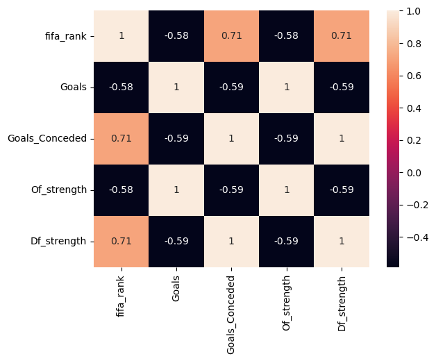

```python
ax = sns.heatmap(df_team.corr(), annot=True)
#plt.show()
def goals_prob(home, away):
    goals_exp_home = df_team["Of_strength"][home] * df_team["Df_strength"][away]
    goals_exp_away = df_team["Of_strength"][away] * df_team["Df_strength"][home]
    return goals_exp_home, goals_exp_away
```

```python
#Uses a Poisson distribution to calculate the expected score of a football match between two contries
def match_score(home,away):
    if home in df_team.index and away in df_team.index:
        exp_home =df_team["Of_strength"][home]*df_team["Df_strength"][away]
        exp_away =df_team["Of_strength"][away]*df_team["Df_strength"][home]
       # return goals_exp_home,goals_exp_away
        prob_home, prob_away, prob_draw = 0, 0, 0
        for x in range(0,11): #number of goals home team
            for y in range(0, 11): #number of goals away team
                p = poisson.pmf(x, exp_home) * poisson.pmf(y, exp_away)
                if x == y:
                    prob_draw += p
                elif x > y:
                    prob_home += p
                else:
                    prob_away += p

        points_home = 3 * prob_home + prob_draw
        points_away = 3 * prob_away + prob_draw
        print(points_home, points_away)
        if(points_home>points_away):
            print(home," is likely to win!")
        else:
            print(away," is likely to win!")
    else:
        return (0, 0)
```

```python
match_score("Croatia","Argentina")
```

```
1.158976845412984 1.540710644417975
Argentina  is likely to win!
```

```python
match_score("France","Morocco")
```

```
1.3265918125907399 1.327133116979872
Morocco  is likely to win!
```

Final

```python
match_score("Argentina","France")
```

```
1.3145081016173172 1.367848657129247
France  is likely to win!
```

```python
#LinearRegression
x = pd.DataFrame(df[['home_team_fifa_rank', 'away_team_fifa_rank', 'home_team_total_fifa_points', 'away_team_total_fifa_points']])
x_train, x_test, y_train, y_test = train_test_split(x, df['home_team_score'] - df['away_team_score'], test_size=0.2, random_state=2)
reg = linear_model.LinearRegression()
reg.fit(x_train,y_train)
y_pred = reg.predict(x_test)
mse = mean_squared_error(y_test,y_pred)
print("MSE Linear Regression:", mse)
print("Coef Linear:", reg.coef_)
```

```
MSE Linear Regression: 3.1262974952963543
Coef Linear: [-0.01878278  0.0201612   0.00027971 -0.00038169]
```

```python
#KNeighborsRegressor n=5
reg2 = KNeighborsRegressor(n_neighbors=5)
reg2.fit(x_train,y_train)
y_pred2 = reg2.predict(x_test)
mse2 = mean_squared_error(y_test,y_pred2)
print("MSE KNN = 5:", mse2)
```

```
MSE KNN = 5: 3.663744292237443
```

```python
#KNeighborsRegressor n=10
reg3 = KNeighborsRegressor(n_neighbors=10)
reg3.fit(x_train,y_train)
y_pred3 = reg3.predict(x_test)
mse3 = mean_squared_error(y_test,y_pred3)
print("MSE KNN = 10:", mse3)
```

```
MSE KNN = 10: 3.3772420091324205
```

```python
#Linear Discriminant Analysis
reg4 = LinearDiscriminantAnalysis()
reg4.fit(x_train,y_train)
y_pred4 = reg4.predict(x_test)
mse4 = mean_squared_error(y_test, y_pred4)
print("MSE LDA:", mse4)
```

```
MSE LDA: 3.6744292237442924
```

```python
#LASSO cross-validation
model = LassoCV()
model.fit(x_train, y_train)
predictions = model.predict(x_test)
print("Test ErrorLasso: " + str(mean_squared_error(y_test, predictions)))
print("Coefficients: ", str(len(model.coef_)))
```

```
Test ErrorLasso: 3.1276527272157084
Coefficients:  4
```

```python
#Ridge cross-validation
model = RidgeCV()
model.fit(x_train, y_train)
predictions = model.predict(x_test)
print("Test ErrorRidge: " + str(mean_squared_error(y_test, predictions)))
print("Coefficients: ", str(len(model.coef_)))
```

```
Test ErrorRidge: 3.1262976700905925
Coefficients:  4
```

By splitting the data using the validation set approach we can test the data against real data. One-fifth of the data was split for the validation set and the training set contained the remaining four-fifths of the data.

Here is a link to the complete Github respository github.com/EthanFalcao/Fifa_world_cup_Machine_Learning